# Ecología

Cristian Gañan - Yonatan Moran - Federico Loaiza

## índices de diversidad

La diversidad es un termino complejo definir, por sus problemas semánticos, conceptuales y técnicos a que está sujeto (Hill, 1973; Ludwing y Reynolds, 1988). Segun PETT (1974), la diversidad, siempre ha sido definida por los índices utilizados para medirla y no ha adquirido la uniformidad requerida para el estableciemiento claro de idea e hipótesis, es decir, que los índices de diversidad son parecidos a los modelos estadísticos que modelan la realidad, pero de una forma u otra son muy convenientes de acuerdo al investigador, pues son ajustados para dar *“lo que deberia dar”*; a pesar de todas la advertencias y custionamientos, los índices de diversidad siguen siendo muy populares entre los ecólogos (Ludwing y Reynolds, 1988).

A continuacion se presentan algunos índices de diversidad calculados, con el fin de analizar los resultados estudiando conceptos como **Riqueza, abundancia, Heterogeneidad, etc**:

### Datos

```r
datos<- read_xlsx("Taller_indices.xlsx")

datos<- datos %>% mutate(PARCELA=as.factor(PARCELA),
                         Individuo= as.numeric(ID_INDV_MU),
                         ESPECIE= as.factor(ESPECIE), N_Cientifico= as.factor(N_Cientifico)) %>%
  slice(1:199)
datos
```

| PARCELA | ID_INDV_MU | DIVISION | CLASE | ORDEN | FAMILIA | GENERO | ESPECIE | N_Cientifico | N_COMUN | DAP_INDIV | H_TOTAL | …13 | Tamaño parcela 500 m^2 | Individuo |
| --- | --- | --- | --- | --- | --- | --- | --- | --- | --- | --- | --- | --- | --- | --- |
| 1 | 1 | Magnoliophyta | Equisetopsida | Malpighiales | Hypericaceae | Vismia | cayennensis | Vismia cayennensis | Carate | 11.14085 | 8.500000 | NA | NA | 1 |
| 1 | 2 | Magnoliophyta | Equisetopsida | Myrtales | Melastomataceae | Miconia | trinervia | Miconia trinervia | Cancobo blanco | 25.81493 | 8.900000 | NA | NA | 2 |
| 1 | 3 | Magnoliophyta | Equisetopsida | Malpighiales | Violaceae | Gloeospermum | sphaerocarpum | Gloeospermum sphaerocarpum | NA | 13.68733 | 7.500000 | NA | NA | 3 |
| 1 | 4 | Magnoliophyta | Equisetopsida | Fabales | Fabaceae | Dussia | lehmanii | Dussia lehmanii | NA | 39.62958 | 19.904486 | NA | NA | 4 |
| 1 | 5 | Magnoliophyta | Equisetopsida | Rosales | Urticaceae | Cecropia | peltata | Cecropia peltata | Yarumo | 13.71916 | 10.900000 | NA | NA | 5 |
| 1 | 6 | Magnoliophyta | Equisetopsida | Malvales | Malvaceae | Pachira | gracilis | Pachira gracilis | NA | 12.92338 | 7.600000 | NA | NA | 6 |
| 1 | 7 | Magnoliophyta | Equisetopsida | Malpighiales | Salicaceae | Tetrathylacium | johansenii | Tetrathylacium johansenii | NA | 10.85437 | 6.700000 | NA | NA | 7 |
| 1 | 8 | Magnoliophyta | Equisetopsida | Malvales | Malvaceae | Guazuma | ulmifolia | Guazuma ulmifolia | Guásimo | 20.14902 | 17.900000 | NA | NA | 8 |
| 1 | 9 | Magnoliophyta | Equisetopsida | Lamiales | Bignoniaceae | Jacaranda | copaia | Jacaranda copaia | Chingale | 18.17549 | 20.000000 | NA | NA | 9 |
| 1 | 10 | Magnoliophyta | Equisetopsida | Ericales | Solanaceae | Solanum | crinitum | Solanum crinitum | NA | 11.14085 | 6.900000 | NA | NA | 10 |
| 1 | 11 | Magnoliophyta | Equisetopsida | Ericales | Solanaceae | Solanum | crinitum | Solanum crinitum | NA | 15.15155 | 14.900000 | NA | NA | 11 |
| 1 | 12 | Magnoliophyta | Equisetopsida | Ericales | Solanaceae | Solanum | crinitum | Solanum crinitum | NA | 25.84676 | 17.000000 | NA | NA | 12 |
| 1 | 13 | Magnoliophyta | Equisetopsida | Ericales | Solanaceae | Solanum | crinitum | Solanum crinitum | NA | 24.28704 | 15.900000 | NA | NA | 13 |
| 1 | 15 | Magnoliophyta | Equisetopsida | Malvales | Malvaceae | Apeiba | tibourbou | Apeiba tibourbou | Peine mono | 21.70873 | 8.900000 | NA | NA | 15 |
| 2 | 11 | Magnoliophyta | Equisetopsida | Sapindales | Anacardiaceae | Spondias | mombin | Spondias mombin | Hobo | 11.01352 | 9.832420 | NA | NA | 11 |
| 2 | 35 | Magnoliophyta | Equisetopsida | Sapindales | Anacardiaceae | Spondias | mombin | Spondias mombin | Hobo | 10.31324 | 9.500000 | NA | NA | 35 |
| 2 | 10 | Magnoliophyta | Equisetopsida | Magnoliales | Annonaceae | Guateria | hirsuta | Guateria hirsuta | NA | 26.03775 | 16.750214 | NA | NA | 10 |
| 2 | 22 | Magnoliophyta | Equisetopsida | Magnoliales | Annonaceae | Guateria | hirsuta | Guateria hirsuta | NA | 13.75099 | 7.000000 | NA | NA | 22 |
| 2 | 31 | Magnoliophyta | Equisetopsida | Lamiales | Bignoniaceae | Jacaranda | copaia | Jacaranda copaia | Chingale | 16.67944 | 21.400000 | NA | NA | 31 |
| 2 | 32 | Magnoliophyta | Equisetopsida | Lamiales | Bignoniaceae | Jacaranda | copaia | Jacaranda copaia | Chingale | 10.18592 | 18.400000 | NA | NA | 32 |
| 2 | 33 | Magnoliophyta | Equisetopsida | Lamiales | Bignoniaceae | Jacaranda | copaia | Jacaranda copaia | Chingale | 19.25775 | 15.500000 | NA | NA | 33 |
| 2 | 29 | Magnoliophyta | Equisetopsida | Malvales | Bixaceae | Cochlospermum | orinocense | Cochlospermum orinocense | Yuco | 19.13042 | 11.400000 | NA | NA | 29 |
| 2 | 17 | Magnoliophyta | Equisetopsida | Malpighiales | Euphorbiaceae | Hura | crepitans | Hura crepitans | Tronador | 10.69521 | 9.623545 | NA | NA | 17 |
| 2 | 28 | Magnoliophyta | Equisetopsida | Malpighiales | Euphorbiaceae | Hura | crepitans | Hura crepitans | Tronador | 27.99854 | 17.338109 | NA | NA | 28 |
| 2 | 8 | Magnoliophyta | Equisetopsida | Fabales | Fabaceae | Inga | goldmanii | Inga goldmanii | Guamo | 19.09859 | 14.168626 | NA | NA | 8 |
| 2 | 24 | Spermatophyta | Equisetopsida | Laurales | Lauraceae | Nectandra | purpurea | Nectandra purpurea | Laurel amarillo | 13.33718 | 10.600000 | NA | NA | 24 |
| 2 | 23 | Magnoliophyta | Equisetopsida | Ericales | Lecythidaceae | Lecythis | mesophylla | Lecythis mesophylla | NA | 18.01634 | 11.300000 | NA | NA | 23 |
| 2 | 34 | Magnoliophyta | Equisetopsida | Malvales | Malvaceae | Apeiba | tibourbou | Apeiba tibourbou | Peine mono | 16.29747 | 12.856565 | NA | NA | 34 |
| 2 | 18 | Magnoliophyta | Equisetopsida | Sapindales | Meliaceae | Guarea | sp1 | Guarea sp1 | NA | 12.60507 | 10.828120 | NA | NA | 18 |
| 2 | 9 | Magnoliophyta | Equisetopsida | Rosales | Moraceae | Sorocea | pubivena | Sorocea pubivena | Leche perra | 18.68479 | 13.985834 | NA | NA | 9 |

[output cut: 169 more lines]

### índice Margalef

El índice de margalef mide la diversidad específica

$$D= \ \frac{S-1}{\ln(N)}$$

```r
data<- datos %>%
  group_by(PARCELA) %>%
  summarise(Margalef= (length(unique(N_Cientifico))-1)/log(NROW(N_Cientifico)))
data
```

| PARCELA | Margalef |
| --- | --- |
| 1 | 3.789232 |
| 2 | 4.913252 |
| 3 | 3.941505 |
| 4 | 3.558670 |
| 5 | 3.775896 |
| 6 | 2.117737 |
| 7 | 5.592014 |
| 8 | 5.101728 |
| 9 | 2.730718 |

La **diversidad específica** consta de dos partes: **Riqueza**[^1] y **Uniformidad**[^2](Odum 1985). Para el conjunto de parcelas que se tienen, la riqueza de especies es realtivamente alta, esto basándose en que los valores menores a 2 denotan una baja riqueza de especies (Mora-Donjuán et al, 2017). Se puede observar en la *Figura 1* que las parcela 7 y 8 tienen un valor mayor a 5 lo que sugiere un valor de riqueza alto, pero no se puede concluir del todo esto, pues hay que tener en cuenta que el área de la parcela influye sobre el resultado, pues según Odum 1985 la diversidad específica tiende a aumentar con el tamaño del área, no se tiene esta información, es decir, en términos generales el bosque tiene un índice de **diverisidad específica** aceptable, pero a nivel de parcela es difícil concluir esto.

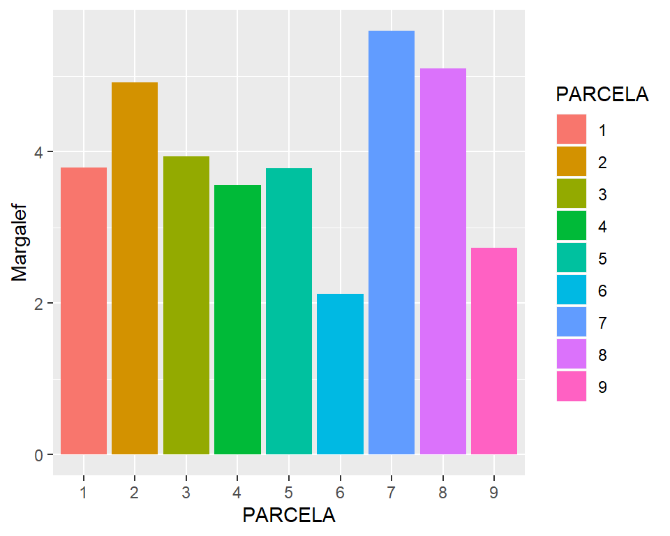

*Figura 1* índice de Margalef

```r
ggplot(data, mapping = aes(x= PARCELA, y= Margalef, fill= PARCELA)) +
  geom_col()
```

### índice Shanon

$$H'= -\sum \ P_i \ \ln(P_i)$$
$P_i= \frac{n_i}{N}$

El índice de **Shanon** mide el contenido de información por individuo en muestras obtenidas al azar provenientes de una comunidad ‘extensa’ de la que se conoce el número total de especies (Mora-Donjuán et al, 2017), su valor normal esta entre 2 y 3. Para el conjunto de parcelas que se tienen se puede decir que, la uniformidad y riqueza del sitio son normales (**Tabla 1**), al obtener un valor promedio de parcelas de $2.3$ lo que sugire un relativo equilibrio, es decir, en muestreos aleatorios donde se saquen especies al azar se esperaría que estas sean diferentes al menos en un porcentaje alto.

```r
datos2<- datos %>% group_by(PARCELA) %>%
  mutate(shanon= NROW(N_Cientifico))

datos2<- datos2 %>% group_by(N_Cientifico, PARCELA) %>%
  mutate(s= (NROW(N_Cientifico)/shanon)*log(NROW(N_Cientifico)/shanon))

datos2<- datos2 %>% group_by(PARCELA, N_Cientifico) %>%
  summarise(sp= (unique(s)))

datos2<- datos2 %>% group_by(PARCELA) %>%
  summarise(shanon= sum(-1*sp))

datos2
```

| PARCELA | shanon |
| --- | --- |
| 1 | 2.242973 |
| 2 | 2.716541 |
| 3 | 2.372350 |
| 4 | 2.350327 |
| 5 | 2.394814 |
| 6 | 1.281634 |
| 7 | 2.809783 |
| 8 | 2.628998 |
| 9 | 1.889159 |

**Tabla 1** *índice de Shanon*

### índice de Pielou

$$J'= \frac{H'}{H'_{max}}$$

Según Moreno, C. E. (2001) este índice mide la proporción de la diversidad observada con relación a la máxima diversidad esperada, basándose en la fórmula es fácil deducir que su valor máximo es $1$ , lo cual quiere decir que entre mas el valor se acerque a $1$ habra más diversidad en el sitio.

Para las parcelas que se tienen es posible decir que son diversas (**Tabla 2**) pues los valores se acercan a uno; esto da información de la diversidad de todo el espacio estudiado en general sería diverso.

```r
datos %>% group_by(PARCELA) %>%
  summarise(S= length(unique(N_Cientifico))) %>%
  mutate(Pielou= datos2$shanon/log(S))
```

| PARCELA | S | Pielou |
| --- | --- | --- |
| 1 | 11 | 0.9353925 |
| 2 | 19 | 0.9226006 |
| 3 | 13 | 0.9249112 |
| 4 | 12 | 0.9458413 |
| 5 | 13 | 0.9336693 |
| 6 | 7 | 0.6586296 |
| 7 | 19 | 0.9542679 |
| 8 | 18 | 0.9095707 |
| 9 | 7 | 0.9708358 |

**Tabla 2** *índice de Pielou*

### índice de Simpson

$$\lambda= \ \sum\ P_i^2$$

Según Moreno, C. E. (2001) índice de manifiesta la probabilidad de que dos individuos tomados al azar de una muestra sean de la misma especie, es decir, que si la probabilidad es alta el bosque sera menos diverso, lo que se puede intuir en una dominancia alta de una sola especie.

Para los datos obtenidos de las parcelas (**Tabla 3**), las probabilidades son bajas, la mas alta de estas no supera el $50\%$ y algunas del orden $>10\%$ lo que podría indicar que si bien el bosque no tiene un dominancia marcada de una especie, sí es posible encontrar grupos mas abundantes que otros.

```r
datos2<- datos %>% group_by(PARCELA) %>%
  mutate(shanon= NROW(N_Cientifico))

datos2<- datos2 %>% group_by(N_Cientifico, PARCELA) %>%
  mutate(Pi= NROW(N_Cientifico)/shanon)

datos2<- datos2 %>% group_by(PARCELA, N_Cientifico) %>%
  summarise(sp= (unique(Pi)))

datos2 %>% group_by(PARCELA) %>%
  summarise(Simpson_Dom= sum(sp^2))
```

| PARCELA | Simpson_Dom |
| --- | --- |
| 1 | 0.1326531 |
| 2 | 0.0821828 |
| 3 | 0.1156463 |
| 4 | 0.1074380 |
| 5 | 0.1076389 |
| 6 | 0.4394464 |
| 7 | 0.0720000 |
| 8 | 0.1020408 |
| 9 | 0.1604938 |

**Tabla 3** *índice de Simpson*

## Bibliografía

- Moreno, C. E. (2001). Métodos para medir la biodiversidad. Programa Iberoamericano de Ciencia y Tecnología para el Desarrollo, CYTED. Retrieved from http://search.ebscohost.com.ezproxy.unal.edu.co/login.aspx?direct=true&db=cat02704a&AN=unc.000254074&lang=es&site=eds-live
- Mora-Donjuán, C. A., Burbano-Vargas, O. N., Méndez-Osorio, C., & Castro-Rojas, D. F. (2017). Evaluación de la biodiversidad y caracterización estructural de un Bosque de Encino (Quercus L.) en la Sierra Madre del Sur, México. Retrieved from http://search.ebscohost.com.ezproxy.unal.edu.co/login.aspx?direct=true&db=edsbas&AN=edsbas.2161E068&lang=es&site=eds-live
- ODUM, E. P. et al. Fundamentos de ecología. [s.l.] : Thomson Editores, S.A. de C.V., 2006. Disponível em: http://search.ebscohost.com.ezproxy.unal.edu.co/login.aspx?direct=true&db=cat02704a&AN=unc.000762294&lang=es&site=eds-live. Acesso em: 19 out. 2019.
- Alcolado, Pedro. (1998). Conceptos e índices relacionados con la diversidad. Avicennia. 7-21.
- LUDWIG, J. A. Y REYNOLDS, J. F. 1988. Statistical Ecology: A primer on methods and computing. John Wiley & Sons, New York, 337 pp.
- PEET, R. K. 1974. The measurement of species diversity. Ann. Rev. Ecol. Syst., 5: 285-307.
[^1]: Se basa en el número total de especies totales.
[^2]: Se basa en la abundancia relativa de la especie.
[^3]: índice de Margalef